# Datos Hidrológicos Ejercicio Explicativo

### Tarea 03: Explorando datos hidrológicos de los ríos Estrella y Banano

##### [Dirección al código fuente](https://github.com/fernando1998-g/Hidrologia)

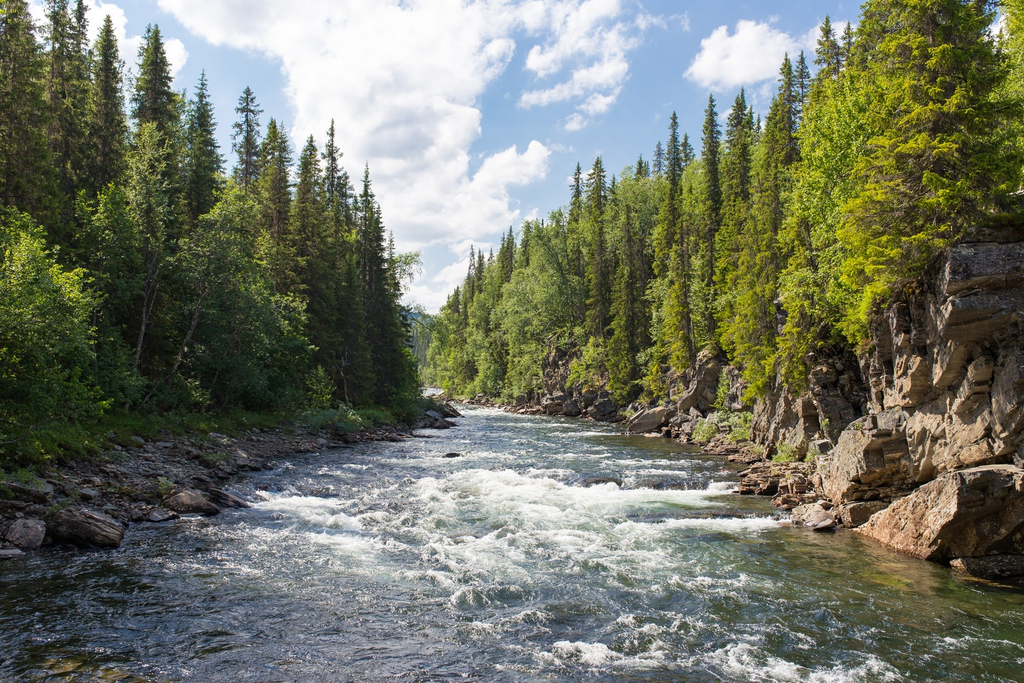

###### Imágen ilustrativa

###### [Frothy tree-lined stream by Jon Flobrant](https://images.unsplash.com/photo-1455577380025-4321f1e1dca7?ixid=MnwxMjA3fDB8MHxwaG90by1wYWdlfHx8fGVufDB8fHx8&ixlib=rb-1.2.1&auto=format&fit=crop&w=1500&q=80)

### Importando los datos a Rstudio con la función (read.csv)

##### Nombre del archivo (FDC.CSV)

```r
inp <- read.csv("FDC.csv", na.strings = "")
```

```r
head(inp)
```

```
##      Tiempo Pandora.mm..637km2. Banano.mm..90km2.
## 1 6/22/1973                7.46             21.02
## 2 6/23/1973                6.17             14.78
## 3 6/24/1973                6.32             27.65
## 4 6/25/1973                7.80             19.68
## 5 6/26/1973                7.72             15.17
## 6 6/27/1973                7.83             23.14
```

### Para visualizar cuantas filas y cuantas columnas tiene el archivo

```r
dim(inp)
```

```
## [1] 3845    3
```

### Para corroborar que el archivo tenga datos completos

```r
inp[!complete.cases(inp),]
```

```
## [1] Tiempo              Pandora.mm..637km2. Banano.mm..90km2.
## <0 rows> (or 0-length row.names)
```

##### **Notas:**

##### **Para eliminar las filas que tengan un espacio vacio (NA) en el caso que se detecte que existan:**

##### newinp <- na.omit(inp)

##### **Para hacer una consulta de alguna función:**

##### ? + función por la que se va a preguntar

##### Ej: ?na.omit

### Generando Grafico para una visualización inicial y general del archivo

##### Hidrograma: Volumen de agua por tiempo en los ríos Estrella y Banano

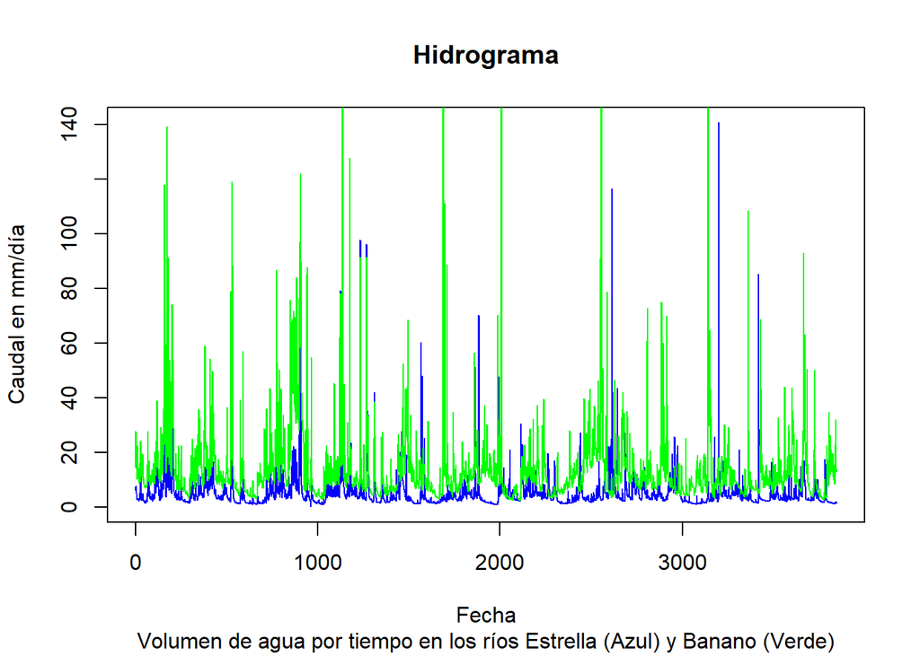

### Estadistica descriptiva básica

##### Promedio de los caudales diarios en un periodo de 10 años

###### Resumen de los datos para la columna 2(Río Estrella) y 3(Río Banano)

```r
summary(inp[, 2:3])
```

```
##  Pandora.mm..637km2. Banano.mm..90km2.
##  Min.   :  0.180     Min.   :  2.43
##  1st Qu.:  2.390     1st Qu.:  6.88
##  Median :  3.590     Median : 10.18
##  Mean   :  5.459     Mean   : 14.28
##  3rd Qu.:  5.900     3rd Qu.: 15.46
##  Max.   :140.650     Max.   :384.00
```

##### **Interpretación:**

###### Max (máximo)

###### Min (Minimo)

###### Mean (promedio (comparando entre los dos ríos se puede ver cual trasporta más agua))

###### Median (mediana = 50% de la distribución )

###### 1st Qu (primer cuartil (25%))

###### 3rd Qu (tercer cuartil (75%))

### Creando un Histograma

##### Para ver la distribución de los datos, del minimo al máximo, dónde está la mayoria de los datos, dónde está el 50% de los datos.

##### **Río Estrella:**

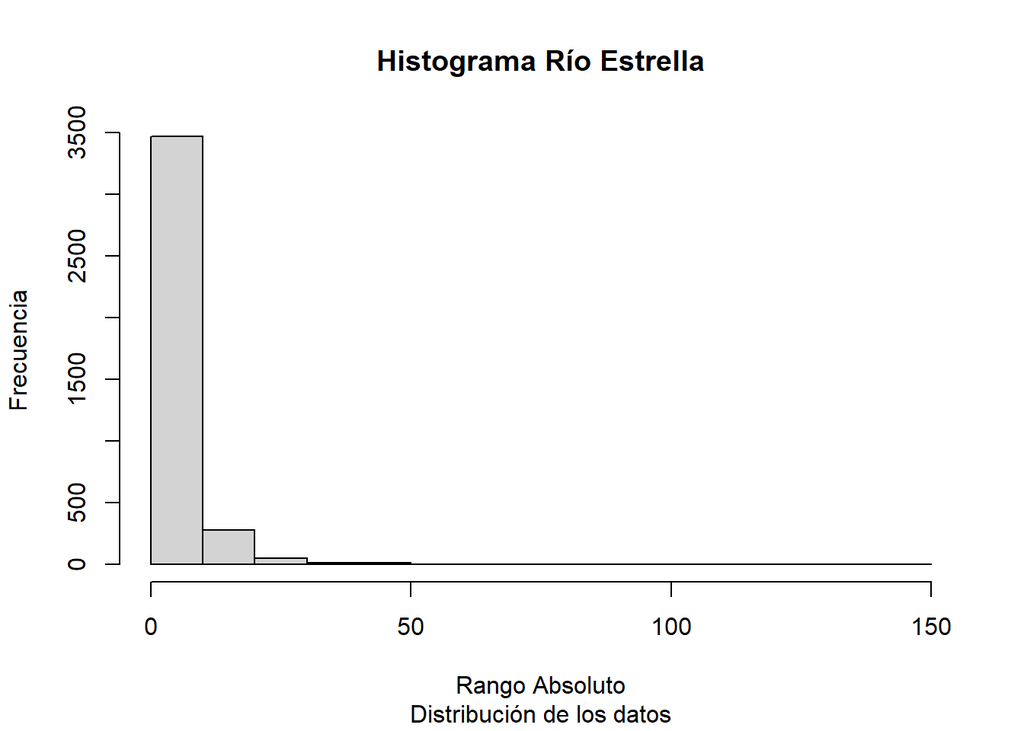

##### **Río Banano:**

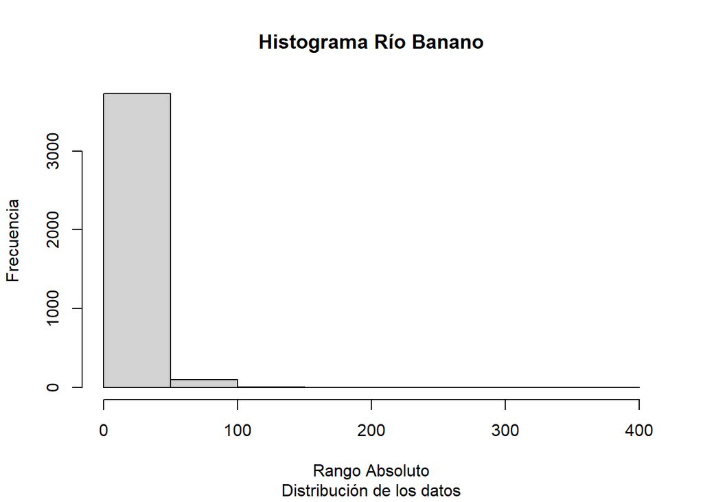

### Asignando Nombres

##### Concatenando los nombres con la función “c”

##### Función attach (se debe usar con cuidado, para calculos básicos es útil)

```r
names(inp) <- c("fecha", "Estrella", "Banano")
attach(inp)
```

##### **Creando un gráfico para el río Estrella:**

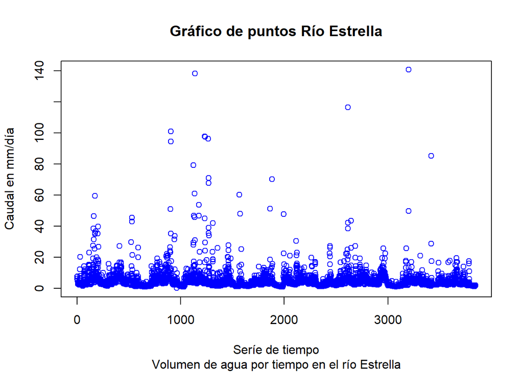

### Agregando valores de tiempo anuales y mensuales

##### Definiendo formanto de la fecha de la serie

```r
tempdate <- strptime(inp[, 1], format= "%d/%m/%Y")
```

### Funciones Apply

##### **Para el río Estrella:**

##### Como son datos de tiempo se debe usar tapply

##### Para el nombre se usa la nomenclatura internacional MAQ

```r
MAQ_Estrella <- tapply(Estrella, format(tempdate, format= "%Y"), FUN=sum)
MAQ_Estrella
```

```
##    1973    1974    1975    1976    1977    1978    1979    1980    1981    1982
##  449.59  956.26  928.51 1368.77  614.70  619.57  849.60  777.60  714.71  609.94
##    1983
##  638.98
```

##### **Repitiendo función tapply para el río Banano:**

```r
MAQ_Banano <- tapply(Banano, format(tempdate, format= "%Y"), FUN=sum)
MAQ_Banano
```

```
##    1973    1974    1975    1976    1977    1978    1979    1980    1981    1982
## 1183.14 2481.46 3006.24 2331.71 1550.98 2147.37 1388.75 2355.04 1396.83 1975.71
##    1983
## 2140.44
```

### Juntando los dos archivos anteriores en uno solo (función “rbind”) y exportarlos (creando un archivo con la función “file=”)

### Función “write” es para escribir un archivo .csv (se especificó ese formato)

```r
write.csv(rbind(MAQ_Estrella, MAQ_Banano), file="MAQ.csv")
```

### Grafico Valores Anuales de Caudal

##### Visualizando las funciones hechas desde tapply

##### El río Banano está representado en puntos y el río Estrella está representado con líneas

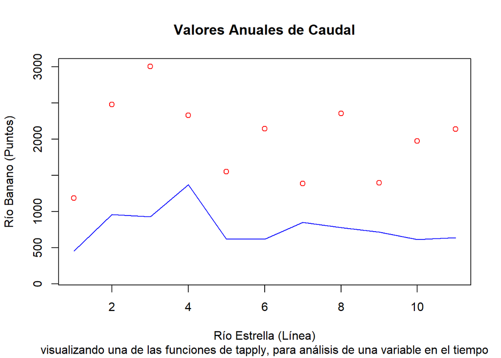

### Promedio acumulado mensual del caudal en un periodo de 10 años

##### La nomenclatura internacional cambia de anual a mensual (MMQ)

```r
MMQ_Estrella <- tapply(Estrella, format(tempdate, format= "%m"), FUN=sum)
MMQ_Banano <- tapply(Banano, format(tempdate, format= "%m"), FUN=sum)
```

### Análisis de correlación

##### **Gráfico Nube de puntos Río estrella contra Río Banano:**

```r
corinp <- cor(inp[,2:3], method = "spearman")
```

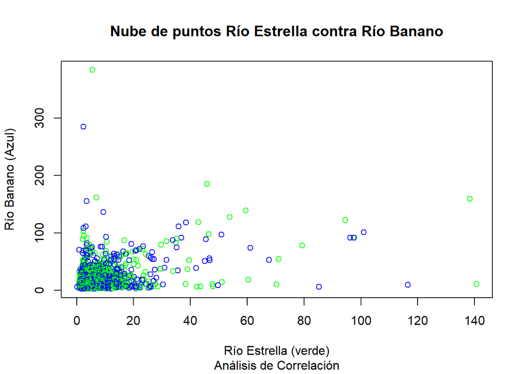

### Calculando una regresión líneal

##### Modelo de regresión lineal con la función lm

##### **Grafico que visualiza algunos diagnosticos(presionando enter en la consola):**

```r
inp.lm <- lm(inp[, 2] ~ inp[, 3], data= inp)
summary(inp.lm)
```

```
##
## Call:
## lm(formula = inp[, 2] ~ inp[, 3], data = inp)
##
## Residuals:
##     Min      1Q  Median      3Q     Max
## -71.297  -2.267  -1.155   0.774 135.889
##
## Coefficients:
##             Estimate Std. Error t value Pr(>|t|)
## (Intercept)  2.70503    0.15174   17.83   <2e-16 ***
## inp[, 3]     0.19290    0.00707   27.28   <2e-16 ***
## ---
## Signif. codes:  0 '***' 0.001 '**' 0.01 '*' 0.05 '.' 0.1 ' ' 1
##
## Residual standard error: 7.025 on 3843 degrees of freedom
## Multiple R-squared:  0.1623, Adjusted R-squared:  0.162
## F-statistic: 744.4 on 1 and 3843 DF,  p-value: < 2.2e-16
```

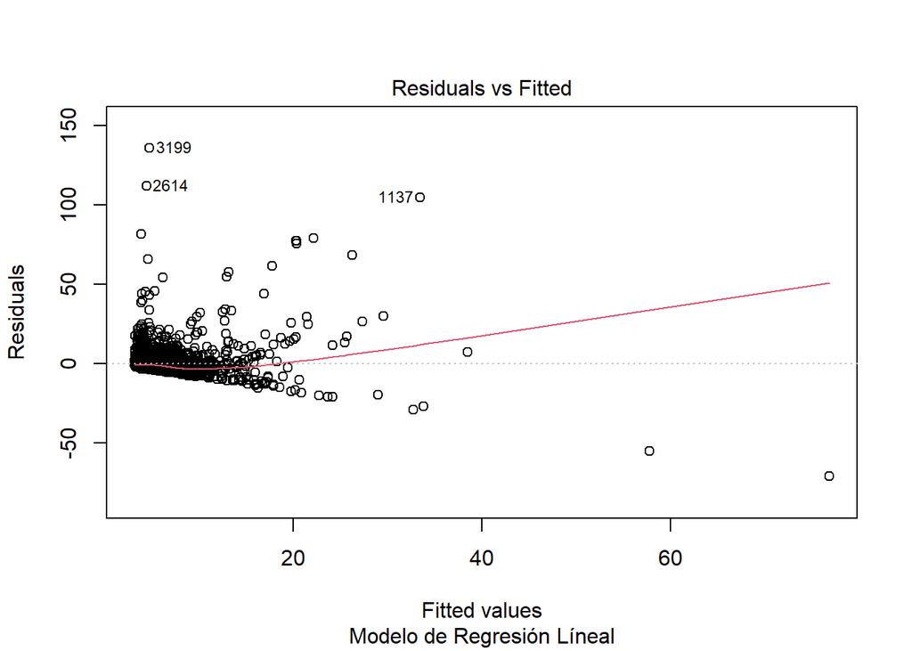

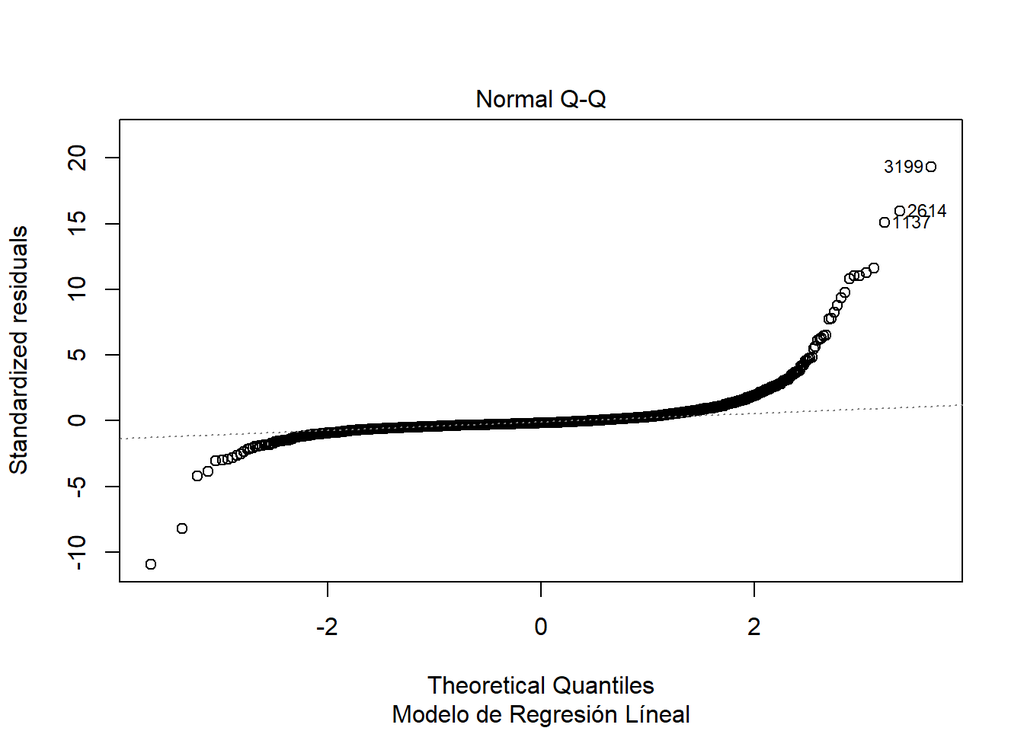

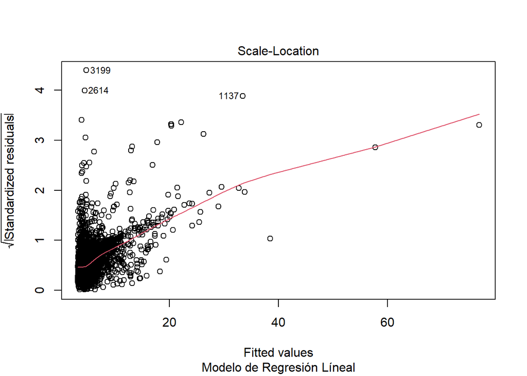

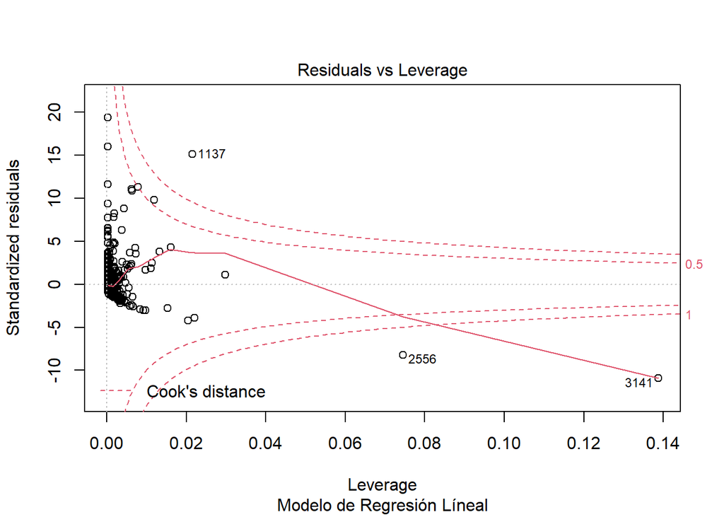